# Hydraulic Traits

Plant hydraulic traits in the xylem functional traits database are most often those derived from, or related to the vulnerability curve of a species. Vulnerability curves describe the increase in hydraulic impairment (or, decrease in conductivity) along an increasing tension gradient (more negative water potentials). Below is a figure of a vulnerability curve:

## P50

#### the xylem tension at which 50% of the maximum hydraulic conductivity is lost

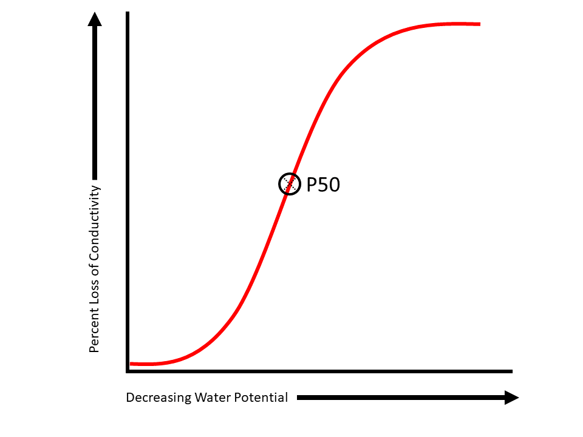

A vulnerability curve with P50 circled.

## P12

#### the xylem tension at which 12% of the maximum hydraulic conductivity is lost

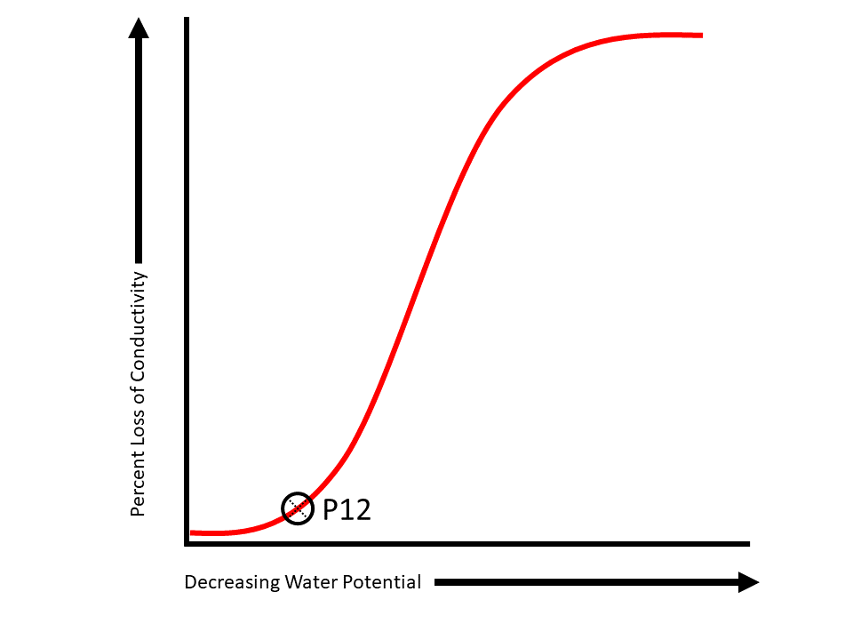

A vulnerability curve with P12 circled.

## P88

#### the xylem tension at which 88% of the maximum hydraulic conductivity is lost

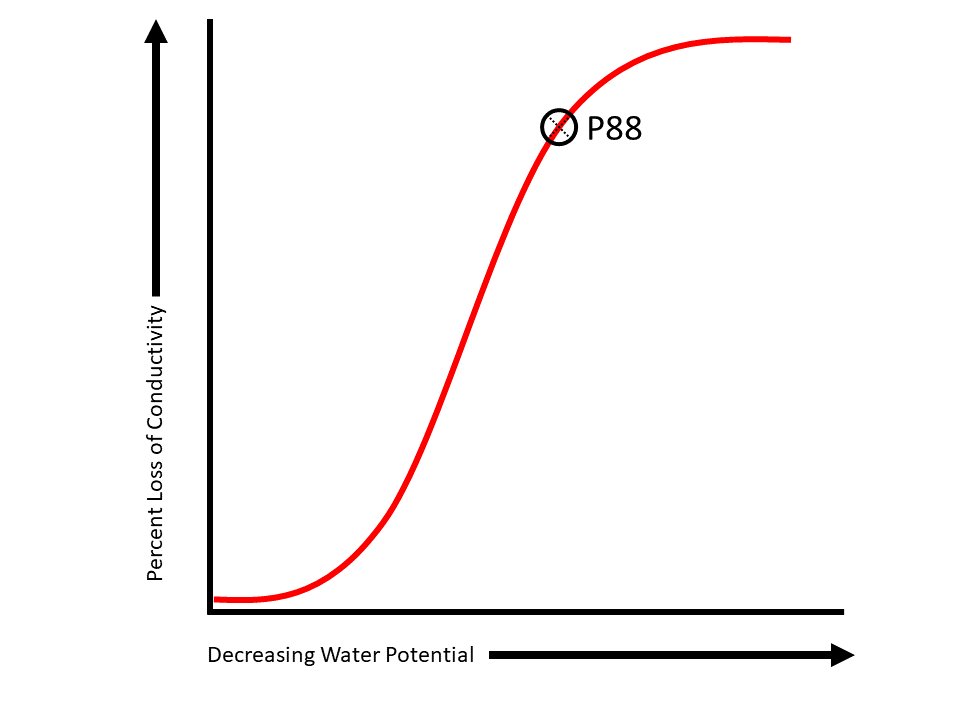

A vulnerability curve with P88 circled.

## Slope

#### Slope of vulnerability curve (% / MPa) = (88-50)/(P88-P50)

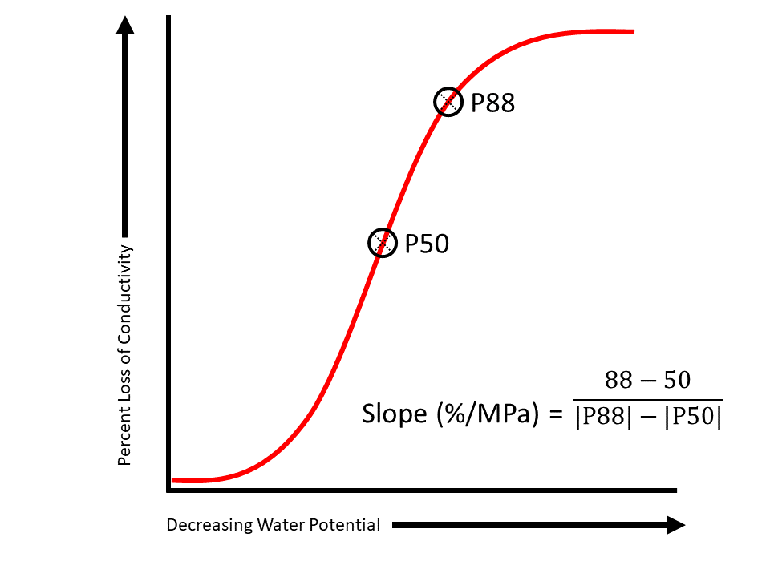

A vulnerability curve with P50, P88 circled, and the equation for slope.

## Curve

#### E = exponential (blue), S = sigmoidal (red), O = other

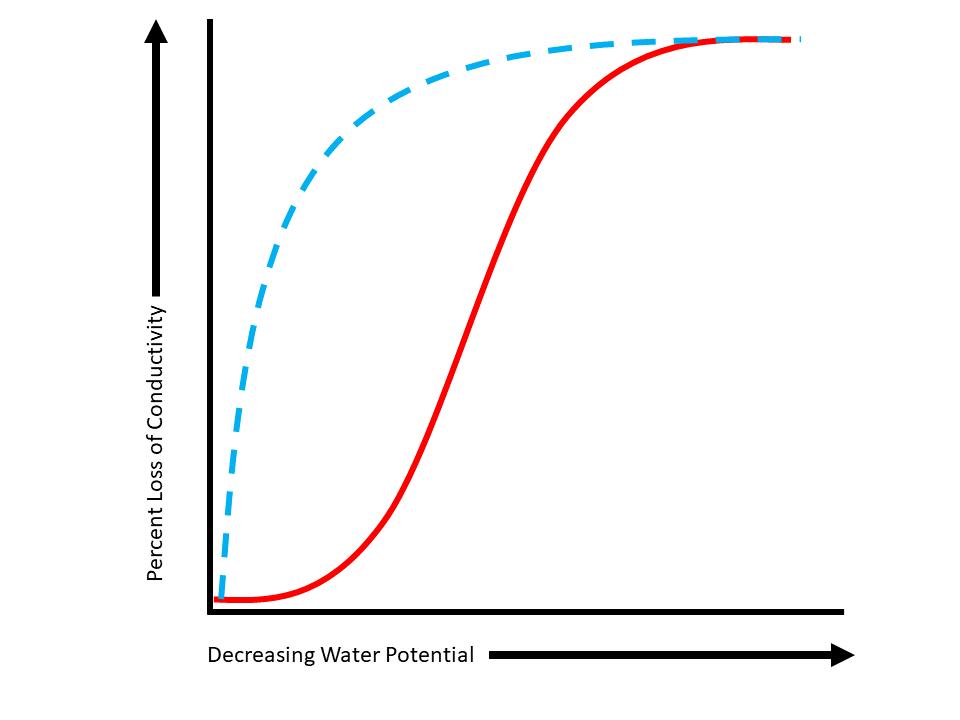

Figure 2: A sigmoidal vulnerability curve (red solid line, ‘S’) and an exponential vulnerability curve (blue dashed line, ‘E’).

## KL

#### (kg m-1 MPa-1 s-1) leaf specific conductivity = xylem conductivity per total area of leaves distal to the measured segment

## ψmin

#### ψp min predawn (MPa) Minimum predawn xylem pressure potential.

#### ψp min midday (MPa) Minimum midday xylem pressure potential.

## Huber value

#### ratio of conducting xylem area per supported leaf area

## Capacitance

#### Sapwood water storage capacity (kg m-3 MPa-1)

# Anatomy

## Av. tracheid length (μm)

#### only for gymnosperms and vesselless angiosperms

## Av. vessel length (cm)

#### only for angiosperms

## Vessel length method

#### vessel length method (silicon injection; air-injection; other)

## Max vessel length

#### (cm) only for angiosperms

## Av. conduit diameter

#### (μm) mean tangential vessel diameter for angiosperms; tangential tracheid diameter for gymnosperms

## dh mean hydraulic diameter (μm)

#### dh mean hydraulic diameter (μm)

## Conduit density per mm2

#### Number of vessels (angiosperms) or tracheids (gymnosperms) per mm

## Vessel grouping index

#### Total number of vessels in a minimum of 25 vessel groups divided by the number of groups counted

## Ac (Intervessel contact fraction)

#### Fraction of the vessel surface area contacting another vessel (%) = perimeter of intervessel wall divided by total vessel wall perimeter

## Pit membrane surface area

#### (µm2) Average pit membrane surface area - earlywood only

## Interconduit pit size

#### (μm) horizontal diameter of a bordered pit at the broadest point (= pit membrane diameter) - earlywood only

## Outer pit aperture diameter

#### (μm) horizontal diameter of the (outer) pit aperture at the broadest point - earlywood only

## Aperture / Pit size

#### Outer pit aperture diameter / interconduit pit size

## Intervessel pit membrane thickness

#### (nm) intervessel pit membrane thickness

## Torus diameter

#### (μm) horizontal diameter of the torus at its broadest point

## Torus overlap

#### (diameter of the torus - diameter of the aperture)/diameter of the torus

## Vestures

#### presence of small protuberances from the secondary cell wall associated with bordered pits of angiosperms

## Fp (pit fraction)

#### The fraction of the conduit wall occupied by interconduit pits, i.e. pit area per total conduit wall area

## Ap (interconduit pit (membrane) area mm2)

#### total interconduit pit (membrane) surface area [Ap = Fp x Avessel/tracheid]

## Porosity

#### diffuse-porosity; ring-porosity; semi-ring-porosity

## Perforation plates

#### Simple; scalariform; mixed (i.e. simple and scalariform)

## Ground tissue

#### tracheids (vasicentric, vascular or true tracheids), libriform fibres, fibres

## Vasicentric tracheids

#### tracheids surrounding vessels (present or absent)

# Mechanical Properties

## Modulus of rupture (MOR)

#### Modulus of rupture (MOR)

## Flexual stiffness (EI)

#### Flexual stiffness (EI)

## Modulus of elasticity (MOE)

#### Modulus of elasticity (MOE)

## t (μm)

#### double intervessel or intertracheid cell wall thickness (µm)

## Theoretical vessel implosion resistance

#### (t/b)2; t = double intervessel or intertracheid cell wall thickness (µm); b = vessel or tracheid lumen diameter (excluding the cell wall)

## ρ (wood specific gravity; g/cm3)

#### oven dry mass/fresh volume [please make a note in the notes column when green mass/volume was measured]

# Leaf data

## SLA (specific leaf area; cm2 g-1)

#### specific leaf area = leaf area to mass ratio

## Total stomata density

#### sum of adaxial and abaxial stomatal densities (number of stomata per cm2)

## Stomatal index

#### [S / (E+S)] * 100, where S is the number of stomata per unit area, and E is the number of epidermal cells per same unit area

## Gs (mol m-2 s-1)

#### Maximum stomatal conductance

## Gsmin (mol m-2 s-1)

#### Minimum stomatal conductance

## Gcut (mol m-2 s-1)

#### Cuticular conductance

## Phenology

#### E = evergreen, W = winter deciduous, D = drought deciduous

## Amax (micromol/m2/s)

#### Photosynthetic capacity (micronol/m2/s)

## D13C

#### big delta 13C (per mill) for leaves

# Location

## Location

#### City, area, location

## Country

#### Country

## Latitude

#### Latitude

## Longitude

#### Longitude

## Provenance Latitude

#### Provenance Latitude

## Provenance Longitude

#### Provenance Longitude

## Altitude

#### Altitude (m)

## Altitude provenance

#### Altitude provenance (m)

# Climate

## Mean annual precipitation

#### (mm) for study area or GBIF queries for species names

## Av annual temperature

#### (C°) for study area or GBIF queries for species names

## Evapotranspiration

#### Evapotranspiration

## Biome

#### TRR = tropical rainforest, TRS = tropical seasonal forest (savanna), TMR = temperate rain forest, TMS = temperate seasonal forest, WDS = woodland/shrubland, DES = deserts, BOT = boreal-tundra

# Database

## Reference

#### Reference from which data was contributed.

## Contributor I

#### Name of the participant who integrated the data

## Contributor II

#### Name of the participant who double-checked the data.

## Notes

#### Any remark made by participants regarding the data.